# 260-2016-10-24

2016-10-23 16:07:07

## Prelude

[video not shown]

## Today's Topics

- Bipolar disorder

## Major affective (emotional) disorders

- Types
  - Bipolar disorder
  - Depression
  - Anxiety
- Heritability
  - *proportion of variance in trait accounted for by genetic factors*
  - Monozygotic: .69
  - Dizygotic: .13

## Up/Down Documentary

[video not shown]

## Bipolar disorder

- Formerly “manic depression” or “manic depressive disorder
- Alternating mood states
  - Mania or hypomania (milder form)
  - Depression
- Cycles 3-6 mos in length, but
  - Rapid cycling (weeks or days)
- Suicide risk 20-60x normal population, [(Baldessarini, Pompili, and Tondo 2006)](http://dx.doi.org/10.1017/S1092852900014681)

## Symptoms

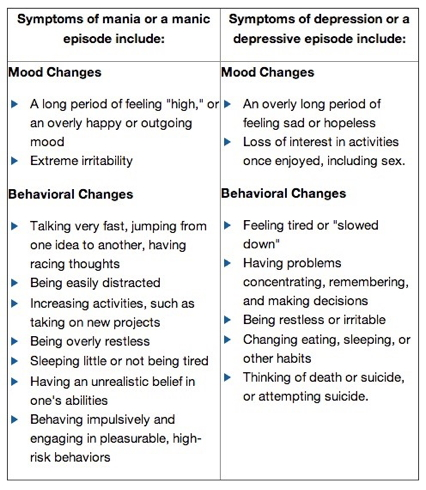

http://www.nimh.nih.gov/health/topics/bipolar-disorder/index.shtml

## Prevalence, subtypes

- 1-3% prevalence
- Subtypes
  - Bipolar I: manic episodes, possible depressive ones
  - Bipolar II: no manic episodes but hypomania + depression

## Genetics

- Overlap between bipolar disorder and schizophrenia
- Genes for voltage-gated Ca++ channels
  - Regulate NT, hormone release
  - Gene expression, cell metabolism
- (Craddock and Sklar 2013)

## Brain responses to emotional faces ≠ depression

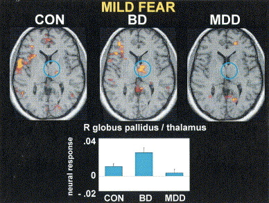

[(Lawrence et al. 2004)](http://dx.doi.org/10.1016/j.biopsych.2003.11.017)

## [(Lawrence et al. 2004)](http://dx.doi.org/10.1016/j.biopsych.2003.11.017)

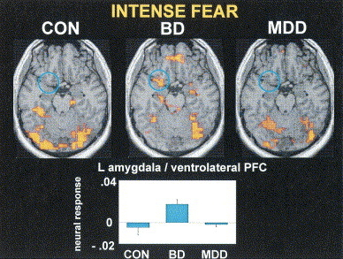

## [(Lawrence et al. 2004)](http://dx.doi.org/10.1016/j.biopsych.2003.11.017)

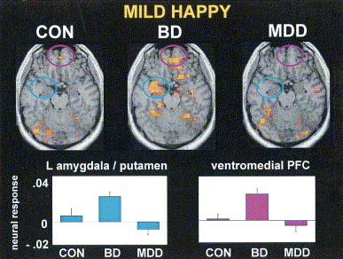

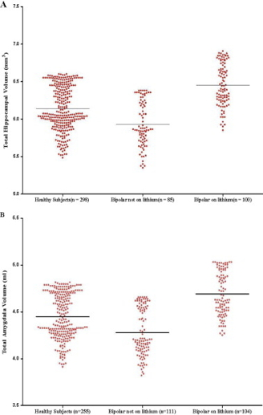

[(Hallahan et al. 2011)](http://dx.doi.org/10.1016/j.biopsych.2010.08.029)

## [(Hallahan et al. 2011)](http://dx.doi.org/10.1016/j.biopsych.2010.08.029)

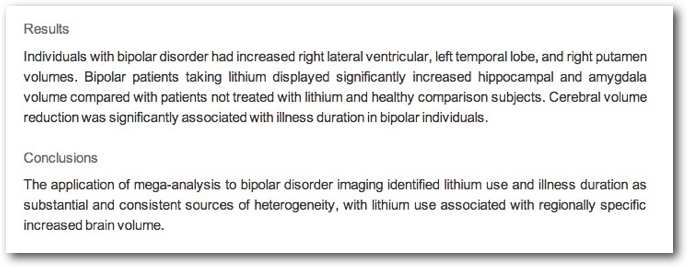

## Drug treatments

- Mood stabilizers
  - Lithium (Li)
  - Valproate (Depakote)
- Anticonvulsants
  - GABA agonists
  - Usually to treat epilepsy
  - e.g. lamotrigine (Lamictal)
- Antipsychotics

## Lithium "discovered" accidentally

- Injections of manic patients' urine with lithium compound (chemical stabilizer) into guinea pig test animals.
- Had calming effect
- John Cade

## Effects of Lithium

- Reduces mania, minimal effects on depressive states
- Increases/preserves PFC, hip, amyg volume
- downregulates DA, glu; upregulates GABA
- modulates 5-HT, NE
- [(Malhi et al. 2013)](http://dx.doi.org/10.1007/s40263-013-0039-0)

## An Unquiet Mind

[figure not shown]

## BP summed-up

- Changes in mood, but ≠ depression
- Genetic + environmental risk
- Changes in emotion processing network activity, size of hippocampus
- But, heterogeneous
- No simple link to a specific NT system

## Next time…

- Depression

## References

Baldessarini, Ross J., Maurizio Pompili, and Leonardo Tondo. 2006. “Suicide in Bipolar Disorder: Risks and Management.” *CNS Spectrums* 11 (06): 465–71. doi:10.1017/S1092852900014681.

Craddock, Nick, and Pamela Sklar. 2013. “Genetics of Bipolar Disorder.” *The Lancet* 381 (9878): 1654–62. doi:10.1016/S0140-6736(13)60855-7.

Hallahan, Brian, John Newell, Jair C. Soares, Paolo Brambilla, Stephen M. Strakowski, David E. Fleck, Tuula Kieseppä, et al. 2011. “Structural Magnetic Resonance Imaging in Bipolar Disorder: An International Collaborative Mega-Analysis of Individual Adult Patient Data.” *Biological Psychiatry*, Bipolar Disorder: Genes and Brain Development, 69 (4): 326–35. doi:10.1016/j.biopsych.2010.08.029.

Lawrence, Natalia S, Andrew M Williams, Simon Surguladze, Vincent Giampietro, Michael J Brammer, Christopher Andrew, Sophia Frangou, Christine Ecker, and Mary L Phillips. 2004. “Subcortical and Ventral Prefrontal Cortical Neural Responses to Facial Expressions Distinguish Patients with Bipolar Disorder and Major Depression.” *Biological Psychiatry* 55 (6): 578–87. doi:10.1016/j.biopsych.2003.11.017.

Malhi, Gin S., Michelle Tanious, Pritha Das, Carissa M. Coulston, and Michael Berk. 2013. “Potential Mechanisms of Action of Lithium in Bipolar Disorder.” *CNS Drugs* 27 (2): 135–53. doi:10.1007/s40263-013-0039-0.